# 06 Topic modeling

H. David Shea

04 Aug 2021

“Topic modeling is a method for unsupervised classification of such documents, similar to clustering on numeric data, which finds natural groups of items even when we’re not sure what we’re looking for.”

“Latent Dirichlet allocation (LDA) is a particularly popular method for fitting a topic model. It treats each document as a mixture of topics, and each topic as a mixture of words. This allows documents to “overlap” each other in terms of content, rather than being separated into discrete groups, in a way that mirrors typical use of natural language."

## Latent Dirichlet allocation

```r
data("AssociatedPress")
AssociatedPress
```

```
#> <<DocumentTermMatrix (documents: 2246, terms: 10473)>>
#> Non-/sparse entries: 302031/23220327
#> Sparsity           : 99%
#> Maximal term length: 18
#> Weighting          : term frequency (tf)
```

```r
ap_lda <- LDA(AssociatedPress, k = 2, control = list(seed = 1234))
ap_lda
```

```
#> A LDA_VEM topic model with 2 topics.
```

### Word-topic probabilities

```r
ap_topics <- tidy(ap_lda, matrix = "beta")
ap_topics %>%
    slice_sample(n = 10) %>%
    kable(caption = "Beta - per-topic-per-word probabilities - for selected AP articles.")
```

Beta - per-topic-per-word probabilities - for selected AP articles.

| topic | term | beta |
| --- | --- | --- |
| 1 | person | 0.0002902 |
| 2 | governor | 0.0004888 |
| 1 | dull | 0.0000391 |
| 2 | physician | 0.0000468 |
| 2 | intentions | 0.0000157 |
| 2 | reynolds | 0.0000000 |
| 2 | handles | 0.0000191 |
| 1 | applauded | 0.0000095 |
| 1 | pittsburgh | 0.0001166 |
| 2 | reviews | 0.0000234 |

It is simple enough to visualize the most common terms likely to be associated with the two topics.

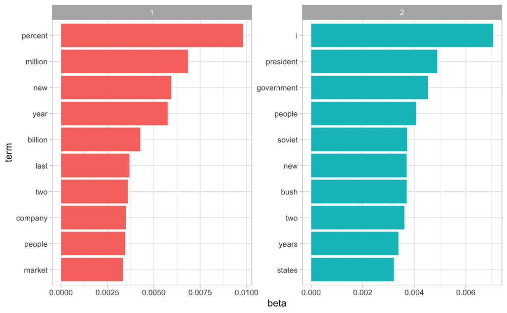

The terms that are most common within each topic

```r
ap_top_terms <- ap_topics %>%
    group_by(topic) %>%
    slice_max(beta, n = 10) %>%
    ungroup() %>%
    arrange(topic,-beta)

ap_top_terms %>%
    mutate(term = reorder_within(term, beta, topic)) %>%
    ggplot(aes(beta, term, fill = factor(topic))) +
    geom_col(show.legend = FALSE) +
    facet_wrap( ~ topic, scales = "free") +
    scale_y_reordered() +
    theme_light()
```

We can also consider the largest difference in beta between the two topics.

```r
beta_wide <- ap_topics %>%
    mutate(topic = paste0("topic", topic)) %>%
    pivot_wider(names_from = topic, values_from = beta) %>%
    filter(topic1 > .001 | topic2 > .001) %>%
    mutate(log_ratio = log2(topic2 / topic1))

beta_wide
```

```
#> # A tibble: 198 x 4
#>    term              topic1      topic2 log_ratio
#>    <chr>              <dbl>       <dbl>     <dbl>
#>  1 administration 0.000431  0.00138         1.68
#>  2 ago            0.00107   0.000842       -0.339
#>  3 agreement      0.000671  0.00104         0.630
#>  4 aid            0.0000476 0.00105         4.46
#>  5 air            0.00214   0.000297       -2.85
#>  6 american       0.00203   0.00168        -0.270
#>  7 analysts       0.00109   0.000000578   -10.9
#>  8 area           0.00137   0.000231       -2.57
#>  9 army           0.000262  0.00105         2.00
#> 10 asked          0.000189  0.00156         3.05
#> # … with 188 more rows
```

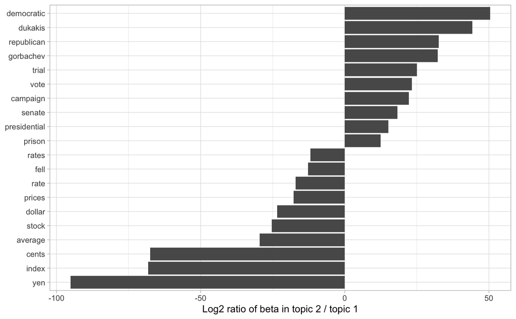

Words with the greatest difference in beta between topic 2 and topic 1

```r
beta_wide %>%
    group_by(direction = log_ratio > 0) %>%
    slice_max(abs(log_ratio), n = 10) %>%
    ungroup() %>%
    mutate(term = reorder(term, log_ratio)) %>%
    ggplot(aes(log_ratio, term)) +
    geom_col() +
    labs(x = "Log2 ratio of beta in topic 2 / topic 1", y = NULL) +
    theme_light()
```

This helps confirm the two topics the algorithm identified as the difference terms are very to the high probability terms visualized above (i.e., topic 1 is “financial” and topic to is “political”).

### Document-topic probabilities

```r
ap_documents <- tidy(ap_lda, matrix = "gamma")
ap_documents %>%
    slice_min(document, n = 10) %>%
    kable(caption = "Gamma - per-document-per-topic probabilities - for selected AP articles.")
```

Gamma - per-document-per-topic probabilities - for selected AP articles.

| document | topic | gamma |
| --- | --- | --- |
| 1 | 1 | 0.2480617 |
| 1 | 2 | 0.7519383 |
| 2 | 1 | 0.3615485 |
| 2 | 2 | 0.6384515 |
| 3 | 1 | 0.5265844 |
| 3 | 2 | 0.4734156 |
| 4 | 1 | 0.3566530 |
| 4 | 2 | 0.6433470 |
| 5 | 1 | 0.1812767 |
| 5 | 2 | 0.8187233 |

Interpretation: the model estimate is that about 25% of the words in document 1 were generated from topic 1.

```r
tidy(AssociatedPress) %>%
  filter(document == 6) %>%
  arrange(desc(count)) %>%
    slice_max(count, n = 10) %>%
    kable(caption = "Most common words in document 6 correspond to topic 2.")
```

Most common words in document 6 correspond to topic 2.

| document | term | count |
| --- | --- | --- |
| 6 | noriega | 16 |
| 6 | panama | 12 |
| 6 | jackson | 6 |
| 6 | powell | 6 |
| 6 | administration | 5 |
| 6 | economic | 5 |
| 6 | general | 5 |
| 6 | i | 5 |
| 6 | panamanian | 5 |
| 6 | american | 4 |
| 6 | letter | 4 |
| 6 | official | 4 |
| 6 | officials | 4 |
| 6 | president | 4 |
| 6 | reagan | 4 |

## Example: the great library heist

Run a test on “known” text to see how good the LDA works.

```r
titles <- c(
    "Twenty Thousand Leagues under the Sea",
    "The War of the Worlds",
    "Pride and Prejudice",
    "Great Expectations"
)

books <- gutenberg_works(title %in% titles) %>%
    gutenberg_download(meta_fields = "title") %>%
    group_by(title) %>% # removing table of contents
    filter(!((title == "Great Expectations") & between(row_number(), 13, 74)),
           !((title == "Pride and Prejudice") & between(row_number(), 13, 135))) %>%
    ungroup()

# divide into documents, each representing one chapter
by_chapter <- books %>%
  group_by(title) %>%
  mutate(chapter = cumsum(str_detect(
    text, regex("^[ ]*chapter ", ignore_case = TRUE)
  ))) %>%
  ungroup() %>%
  filter(chapter > 0) %>%
  unite(document, title, chapter)

# split into words
by_chapter_word <- by_chapter %>%
  unnest_tokens(word, text)

# find document-word counts
word_counts <- by_chapter_word %>%
  anti_join(stop_words, by = "word") %>%
  count(document, word, sort = TRUE) %>%
  ungroup()

word_counts %>%
    slice_max(n, n = 10) %>%
    kable(caption = "Word counts for four novels.")
```

Word counts for four novels.

| document | word | n |
| --- | --- | --- |
| Great Expectations_57 | joe | 88 |
| Great Expectations_7 | joe | 70 |
| Great Expectations_17 | biddy | 63 |
| Great Expectations_27 | joe | 58 |
| Great Expectations_38 | estella | 58 |
| Great Expectations_2 | joe | 56 |
| Great Expectations_23 | pocket | 53 |
| Great Expectations_15 | joe | 50 |
| Great Expectations_18 | joe | 50 |
| The War of the Worlds_16 | brother | 50 |

### LDA on chapters

```r
chapters_dtm <- word_counts %>%
    cast_dtm(document, word, n)

chapters_dtm
```

```
#> <<DocumentTermMatrix (documents: 193, terms: 18314)>>
#> Non-/sparse entries: 105610/3428992
#> Sparsity           : 97%
#> Maximal term length: 19
#> Weighting          : term frequency (tf)
```

```r
chapters_lda <- LDA(chapters_dtm, k = 4, control = list(seed = 1234))

chapters_lda
```

```
#> A LDA_VEM topic model with 4 topics.
```

```r
chapter_topics <- tidy(chapters_lda, matrix = "beta")

chapter_topics %>%
    slice_head(n = 10) %>%
    kable(caption = "Beta - per-topic-per-term probabilities - for four novels.")
```

Beta - per-topic-per-term probabilities - for four novels.

| topic | term | beta |
| --- | --- | --- |
| 1 | joe | 0.0125618 |
| 2 | joe | 0.0000000 |
| 3 | joe | 0.0000000 |
| 4 | joe | 0.0000000 |
| 1 | biddy | 0.0041389 |
| 2 | biddy | 0.0000000 |
| 3 | biddy | 0.0000000 |
| 4 | biddy | 0.0000000 |
| 1 | estella | 0.0043022 |
| 2 | estella | 0.0000000 |

```r
top_terms <- chapter_topics %>%
  group_by(topic) %>%
  slice_max(beta, n = 5) %>%
  ungroup() %>%
  arrange(topic, -beta)

top_terms %>%
    kable(caption = "Top terms within each topic for four novels.")
```

Top terms within each topic for four novels.

| topic | term | beta |
| --- | --- | --- |
| 1 | joe | 0.0125618 |
| 1 | miss | 0.0069131 |
| 1 | time | 0.0065458 |
| 1 | pip | 0.0059178 |
| 1 | looked | 0.0057931 |
| 2 | captain | 0.0153932 |
| 2 | nautilus | 0.0130383 |
| 2 | sea | 0.0088463 |
| 2 | nemo | 0.0087006 |
| 2 | ned | 0.0080236 |
| 3 | elizabeth | 0.0157928 |
| 3 | darcy | 0.0098672 |
| 3 | bennet | 0.0077773 |
| 3 | miss | 0.0075422 |
| 3 | jane | 0.0073007 |
| 4 | people | 0.0069482 |
| 4 | martians | 0.0067670 |
| 4 | black | 0.0054525 |
| 4 | time | 0.0053846 |
| 4 | night | 0.0045289 |

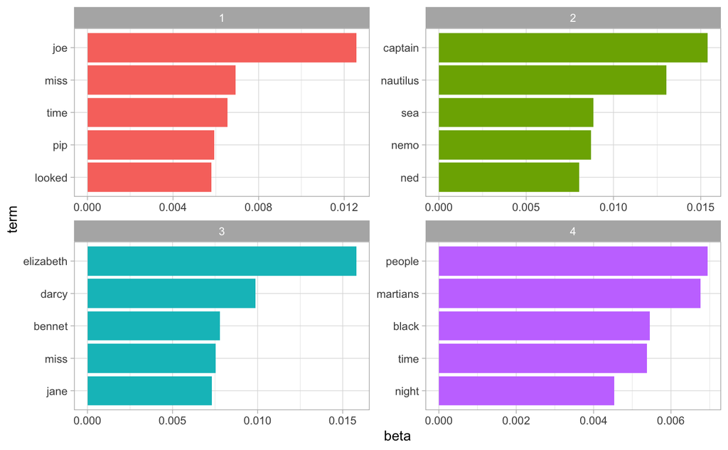

The terms that are most common within each topic

```r
top_terms %>%
    mutate(term = reorder_within(term, beta, topic)) %>%
    ggplot(aes(beta, term, fill = factor(topic))) +
    geom_col(show.legend = FALSE) +
    facet_wrap( ~ topic, scales = "free") +
    scale_y_reordered() +
    theme_light()
```

“These topics are pretty clearly associated with the four books!”

- 1 - “pip” and “joe” from *Great Expectations*
- 2 - “captain” and “nautilus” from *Twenty Thousand Leagues under the Sea*
- 3 - “elizabeth” and “darcy” from *Pride and Prejudice*
- 4 - “martians” and “black” and “night” from *The War of the Worlds*

### Per-document classification

```r
chapters_gamma <- tidy(chapters_lda, matrix = "gamma")

chapters_gamma %>%
    slice_head(n = 10) %>%
    kable(caption = "Gamma - per-document-per-topic probabilities - for four novels.")
```

Gamma - per-document-per-topic probabilities - for four novels.

| document | topic | gamma |
| --- | --- | --- |
| Great Expectations_57 | 1 | 0.9999463 |
| Great Expectations_7 | 1 | 0.9999433 |
| Great Expectations_17 | 1 | 0.9999169 |
| Great Expectations_27 | 1 | 0.9999242 |
| Great Expectations_38 | 1 | 0.9999486 |
| Great Expectations_2 | 1 | 0.9999331 |
| Great Expectations_23 | 1 | 0.8866287 |
| Great Expectations_15 | 1 | 0.9999435 |
| Great Expectations_18 | 1 | 0.9999499 |
| The War of the Worlds_16 | 1 | 0.0000147 |

“Now that we have these topic probabilities, we can see how well our unsupervised learning did at distinguishing the four books. We’d expect that chapters within a book would be found to be mostly (or entirely), generated from the corresponding topic.”

```r
chapters_gamma <- chapters_gamma %>%
    separate(document,
             c("title", "chapter"),
             sep = "_",
             convert = TRUE)

chapters_gamma %>%
    slice_head(n = 10) %>%
    kable(caption = "Gamma - per-document-per-topic probabilities - for four novels.")
```

Gamma - per-document-per-topic probabilities - for four novels.

| title | chapter | topic | gamma |
| --- | --- | --- | --- |
| Great Expectations | 57 | 1 | 0.9999463 |
| Great Expectations | 7 | 1 | 0.9999433 |
| Great Expectations | 17 | 1 | 0.9999169 |
| Great Expectations | 27 | 1 | 0.9999242 |
| Great Expectations | 38 | 1 | 0.9999486 |
| Great Expectations | 2 | 1 | 0.9999331 |
| Great Expectations | 23 | 1 | 0.8866287 |
| Great Expectations | 15 | 1 | 0.9999435 |
| Great Expectations | 18 | 1 | 0.9999499 |
| The War of the Worlds | 16 | 1 | 0.0000147 |

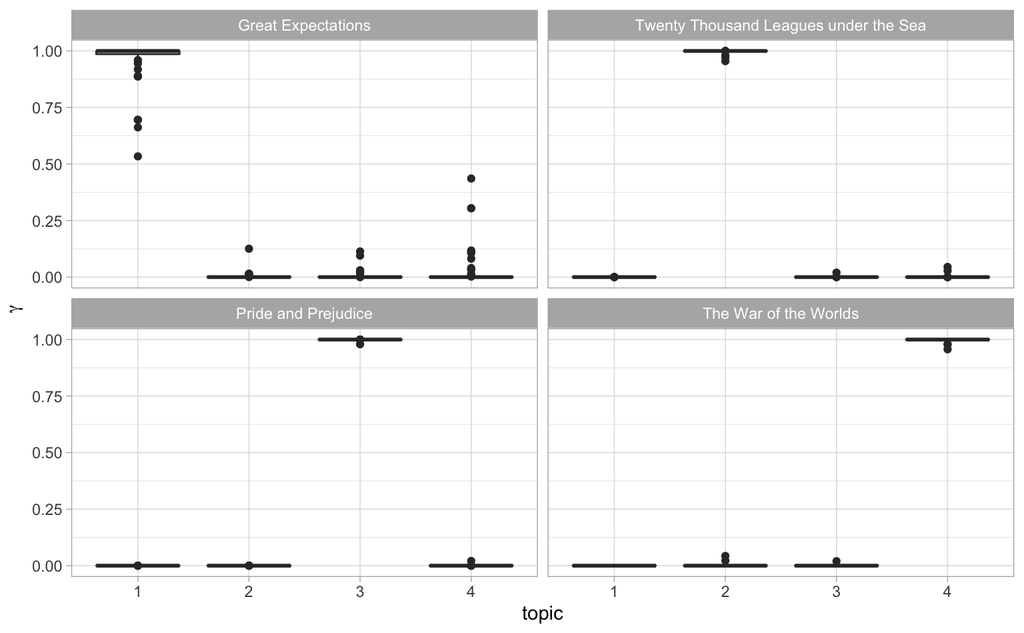

The gamma probabilities for each chapter within each book

```r
# reorder titles in order of topic 1, topic 2, etc before plotting
chapters_gamma %>%
    mutate(title = reorder(title, gamma * topic)) %>%
    ggplot(aes(factor(topic), gamma)) +
    geom_boxplot() +
    facet_wrap( ~ title) +
    labs(x = "topic", y = expression(gamma)) +
    theme_light()
```

Indeed, *Twenty Thousand Leagues under the Sea*, *Pride and Prejudice*, *The War of the Worlds* were almost uniquely identified as a single topic per book.

It does look like *Great E#xpectations* (which should be identified with topic 1) has chapters associated with other topics.

We can also look by chapter to see if there are cases of entire chapters associated with the topic most closely associated with a different book.

```r
chapter_classifications <- chapters_gamma %>%
    group_by(title, chapter) %>%
    slice_max(gamma, n = 1) %>%
    ungroup()

chapter_classifications %>%
    slice_head(n = 10) %>%
    kable()
```

| title | chapter | topic | gamma |
| --- | --- | --- | --- |
| Great Expectations | 1 | 1 | 0.6953004 |
| Great Expectations | 2 | 1 | 0.9999331 |
| Great Expectations | 3 | 1 | 0.9596901 |
| Great Expectations | 4 | 1 | 0.9999342 |
| Great Expectations | 5 | 1 | 0.9999422 |
| Great Expectations | 6 | 1 | 0.9996857 |
| Great Expectations | 7 | 1 | 0.9999433 |
| Great Expectations | 8 | 1 | 0.9999467 |
| Great Expectations | 9 | 1 | 0.9999113 |
| Great Expectations | 10 | 1 | 0.9999077 |

```r
book_topics <- chapter_classifications %>%
    count(title, topic) %>%
    group_by(title) %>%
    slice_max(n, n = 1) %>%
    ungroup() %>%
    transmute(consensus = title, topic)

chapter_classifications %>%
    inner_join(book_topics, by = "topic") %>%
    filter(title != consensus)
```

```
#> # A tibble: 0 x 5
#> # … with 5 variables: title <chr>, chapter <int>, topic <int>, gamma <dbl>,
#> #   consensus <chr>
```

### By word assignments: `augment()`

Here we look at which words in the document were assigned to which topic by the LDA.

```r
assignments <- augment(chapters_lda, data = chapters_dtm)

assignments %>%
    slice_head(n = 10) %>%
    kable()
```

| document | term | count | .topic |
| --- | --- | --- | --- |
| Great Expectations_57 | joe | 88 | 1 |
| Great Expectations_7 | joe | 70 | 1 |
| Great Expectations_17 | joe | 5 | 1 |
| Great Expectations_27 | joe | 58 | 1 |
| Great Expectations_2 | joe | 56 | 1 |
| Great Expectations_23 | joe | 1 | 1 |
| Great Expectations_15 | joe | 50 | 1 |
| Great Expectations_18 | joe | 50 | 1 |
| Great Expectations_9 | joe | 44 | 1 |
| Great Expectations_13 | joe | 40 | 1 |

```r
assignments <- assignments %>%
    separate(document,
             c("title", "chapter"),
             sep = "_",
             convert = TRUE) %>%
    inner_join(book_topics, by = c(".topic" = "topic"))

assignments %>%
    slice_head(n = 10) %>%
    kable()
```

| title | chapter | term | count | .topic | consensus |
| --- | --- | --- | --- | --- | --- |
| Great Expectations | 57 | joe | 88 | 1 | Great Expectations |
| Great Expectations | 7 | joe | 70 | 1 | Great Expectations |
| Great Expectations | 17 | joe | 5 | 1 | Great Expectations |
| Great Expectations | 27 | joe | 58 | 1 | Great Expectations |
| Great Expectations | 2 | joe | 56 | 1 | Great Expectations |
| Great Expectations | 23 | joe | 1 | 1 | Great Expectations |
| Great Expectations | 15 | joe | 50 | 1 | Great Expectations |
| Great Expectations | 18 | joe | 50 | 1 | Great Expectations |
| Great Expectations | 9 | joe | 44 | 1 | Great Expectations |
| Great Expectations | 13 | joe | 40 | 1 | Great Expectations |

We can use this data to visualize a **confusion matrix**, showing how often words from one book were assigned to the consensus topic of another book.

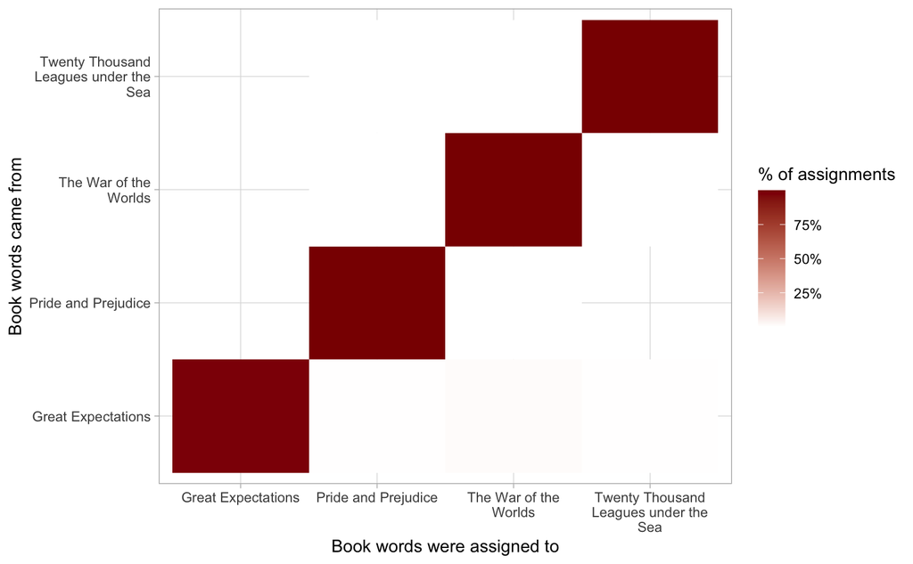

Confusion matrix showing where LDA assigned the words from each book. Each row of this table represents the true book each word came from, and each column represents what book it was assigned to.

```r
assignments %>%
    count(title, consensus, wt = count) %>%
    mutate(across(c(title, consensus), ~ str_wrap(., 20))) %>%
    group_by(title) %>%
    mutate(percent = n / sum(n)) %>%
    ggplot(aes(consensus, title, fill = percent)) +
    geom_tile() +
    scale_fill_gradient2(high = "darkred", label = percent_format()) +
    theme_minimal() +
    theme(axis.text.x = element_text(angle = 90, hjust = 1),
          panel.grid = element_blank()) +
    labs(x = "Book words were assigned to",
         y = "Book words came from",
         fill = "% of assignments") +
    theme_light()
```

```r
wrong_words <- assignments %>%
    filter(title != consensus)

wrong_words %>%
    slice_head(n = 10) %>%
    kable()
```

| title | chapter | term | count | .topic | consensus |
| --- | --- | --- | --- | --- | --- |
| Great Expectations | 46 | captain | 1 | 2 | Twenty Thousand Leagues under the Sea |
| Great Expectations | 32 | captain | 1 | 2 | Twenty Thousand Leagues under the Sea |
| The War of the Worlds | 17 | captain | 5 | 2 | Twenty Thousand Leagues under the Sea |
| Great Expectations | 54 | sea | 2 | 2 | Twenty Thousand Leagues under the Sea |
| Great Expectations | 54 | water | 15 | 2 | Twenty Thousand Leagues under the Sea |
| Great Expectations | 1 | water | 1 | 4 | The War of the Worlds |
| Great Expectations | 54 | road | 1 | 4 | The War of the Worlds |
| Great Expectations | 54 | people | 1 | 4 | The War of the Worlds |
| Great Expectations | 1 | people | 1 | 4 | The War of the Worlds |
| Great Expectations | 21 | people | 1 | 4 | The War of the Worlds |

```r
wrong_words %>%
    count(title, consensus, term, wt = count) %>%
    ungroup() %>%
    arrange(desc(n)) %>%
    slice_max(n, n = 10) %>%
    kable()
```

| title | consensus | term | n |
| --- | --- | --- | --- |
| Great Expectations | Pride and Prejudice | galley | 16 |
| Great Expectations | Twenty Thousand Leagues under the Sea | water | 15 |
| Great Expectations | Pride and Prejudice | jane | 13 |
| Great Expectations | The War of the Worlds | steamer | 12 |
| Great Expectations | Twenty Thousand Leagues under the Sea | board | 8 |
| Great Expectations | The War of the Worlds | smoke | 7 |
| Great Expectations | The War of the Worlds | sun | 7 |
| Great Expectations | The War of the Worlds | black | 6 |
| Great Expectations | The War of the Worlds | sky | 6 |
| Great Expectations | The War of the Worlds | tilted | 6 |

```r
word_counts %>%
  filter(word == "flopson")
```

```
#> # A tibble: 3 x 3
#>   document              word        n
#>   <chr>                 <chr>   <int>
#> 1 Great Expectations_22 flopson    10
#> 2 Great Expectations_23 flopson     7
#> 3 Great Expectations_33 flopson     1
```

## Alternative LDA implementations

Still problems with Java on Mac M1 machines and the mallet package requires Java.